# explore

### Use data

Use one of the prepared datasets to explore:

- `use_data_beer()`
- `use_data_diamonds()`
- `use_data_iris()`
- `use_data_mpg()`
- `use_data_mtcars()`
- `use_data_penguins()`
- `use_data_starwars()`
- `use_data_titanic()`
- `use_data_wordle()`

```r
use_data_beer() %>% describe()
```

```
#> # A tibble: 11 × 8
#>    variable          type     na na_pct unique    min    mean    max
#>    <chr>             <chr> <int>  <dbl>  <int>  <dbl>   <dbl>  <dbl>
#>  1 name              chr       0    0      161   NA     NA      NA
#>  2 brand             chr       0    0       29   NA     NA      NA
#>  3 country           chr       0    0        3   NA     NA      NA
#>  4 year              dbl       0    0        1 2023   2023    2023
#>  5 type              chr       0    0        3   NA     NA      NA
#>  6 color_dark        dbl       0    0        2    0      0.09    1
#>  7 alcohol_vol_pct   dbl       2    1.2     35    0      4.32    8.4
#>  8 original_wort     dbl       5    3.1     54    5.1   11.3    18.3
#>  9 energy_kcal_100ml dbl      11    6.8     34   20     39.9    62
#> 10 carb_g_100ml      dbl      16    9.9     44    1.5    3.53    6.7
#> 11 sugar_g_100ml     dbl      16    9.9     26    0      0.72    4.6
```

### Create data

Use one of the prepared datasets to explore:

- `create_data_abtest()`
- `create_data_app()`
- `create_data_buy()`
- `create_data_churn()`
- `create_data_esoteric()`
- `create_data_newsletter()`
- `create_data_person()`
- `create_data_unfair()`
- `create_data_random()`

```r
# create dataset and describe it
data <- create_data_app(obs = 100)
describe(data)
```

```
#> # A tibble: 7 × 8
#>   variable     type     na na_pct unique   min    mean   max
#>   <chr>        <chr> <int>  <dbl>  <int> <dbl>   <dbl> <dbl>
#> 1 os           chr       0      0      3    NA   NA       NA
#> 2 free         int       0      0      2     0    0.62     1
#> 3 downloads    int       0      0     99   255 6704.   18386
#> 4 rating       dbl       0      0      5     1    3.44     5
#> 5 type         chr       0      0     10    NA   NA       NA
#> 6 updates      dbl       0      0     72     1   45.6     99
#> 7 screen_sizes dbl       0      0      5     1    2.61     5
```

```r
# create dataset and describe it
data <- create_data_random(obs = 100, vars = 5)
describe(data)
```

```
#> # A tibble: 7 × 8
#>   variable   type     na na_pct unique   min  mean   max
#>   <chr>      <chr> <int>  <dbl>  <int> <dbl> <dbl> <dbl>
#> 1 id         int       0      0    100     1 50.5    100
#> 2 target_ind int       0      0      2     0  0.53     1
#> 3 var_1      int       0      0     61     1 51.4     99
#> 4 var_2      int       0      0     63     1 48.6     98
#> 5 var_3      int       0      0     62     1 49.2    100
#> 6 var_4      int       0      0     68     0 48.6    100
#> 7 var_5      int       0      0     64     2 51.9     99
```

You can build you own random dataset by using `create_data_empty()` and `add_var_random_*()` functions:

```r
# create dataset and describe it
data <- create_data_empty(obs = 1000) %>%
  add_var_random_01("target") %>%
  add_var_random_dbl("age", min_val = 18, max_val = 80) %>%
  add_var_random_cat("gender",
                     cat = c("male", "female", "other"),
                     prob = c(0.4, 0.4, 0.2)) %>%
  add_var_random_starsign() %>%
  add_var_random_moon()
describe(data)
```

```
#> # A tibble: 5 × 8
#>   variable        type     na na_pct unique   min  mean   max
#>   <chr>           <chr> <int>  <dbl>  <int> <dbl> <dbl> <dbl>
#> 1 target          int       0      0      2   0    0.51   1
#> 2 age             dbl       0      0   1000  18.2 49.1   80.0
#> 3 gender          chr       0      0      3  NA   NA     NA
#> 4 random_starsign chr       0      0     12  NA   NA     NA
#> 5 random_moon     chr       0      0      4  NA   NA     NA
```

```r
data %>% select(random_starsign, random_moon) %>% explore_all()
```

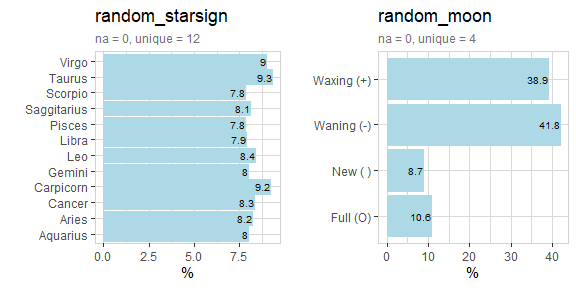

### Basic data cleaning

To clean a variable you can use `clean_var`. With one line of code you can rename a variable, replace NA-values and set a minimum and maximum for the value.

```r
iris %>%
  clean_var(Sepal.Length,
            min_val = 4.5,
            max_val = 7.0,
            na = 5.8,
            name = "sepal_length") %>%
  describe()
```

```
#> # A tibble: 5 × 8
#>   variable     type     na na_pct unique   min  mean   max
#>   <chr>        <chr> <int>  <dbl>  <int> <dbl> <dbl> <dbl>
#> 1 sepal_length dbl       0      0     26   4.5  5.81   7
#> 2 Sepal.Width  dbl       0      0     23   2    3.06   4.4
#> 3 Petal.Length dbl       0      0     43   1    3.76   6.9
#> 4 Petal.Width  dbl       0      0     22   0.1  1.2    2.5
#> 5 Species      fct       0      0      3  NA   NA     NA
```

To drop variables or observations you can use `drop_var_*()` and `drop_obs_*()` functions.

```r
use_data_penguins() %>%
  describe_tbl()
```

```
#> 344 observations with 8 variables
#> 11 observations containing missings (NA)
#> 5 variables containing missings (NA)
#> 0 variables with no variance
```

```r
use_data_penguins() %>%
  drop_obs_with_na() %>%
  describe_tbl()
```

```
#> 333 observations with 8 variables
#> 0 observations containing missings (NA)
#> 0 variables containing missings (NA)
#> 0 variables with no variance
```

### Create notebook

Create an RMarkdown template to explore your own data. Set output_dir (existing file may be overwritten)

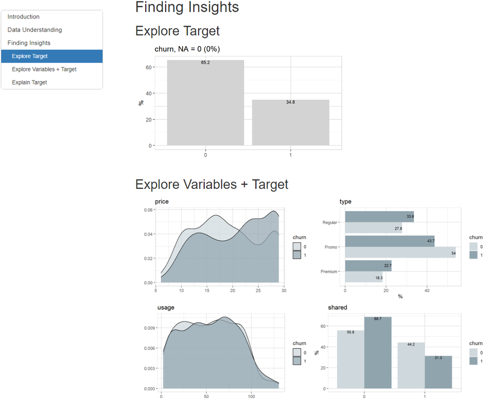

```r
create_notebook_explore(
  output_dir = tempdir(),
  output_file = "notebook-explore.Rmd")
```